# Diet, revisited

1. Add missing models are re-run.
   - Prerequisites:
     - choose canopy cover categories
     - make canopy cover rasters
     - make older forest rasters
2. Fix some stuff I’ve been doing wrong.
   - remake landcover rasters at 100m scale
   - rerun diet breakdown with counts Next steps:
   - compare counts and biomass breakdowns
3. Run the models also for physical specimen data.
   - Prerequisites:
     - finish cleaning physical data
     - determine if there’s a cutoff for sample size
   - Next steps:
     - compare results from camera and physical data
4. Compare diet between coastal and transition zones.
   - Prerequisites:
     - assign each site to cs or tz
   - Next steps:
     - compare results from camera and physical data

Compare biomass and counts for cameras.

| nest | prop.mm.mass | prop.mm.count |
| --- | --- | --- |
| UTZ2019 | 0.9123421 | 0.8700000 |
| MTC2019 | 0.7750943 | 0.6226415 |
| MTF2019 | 0.8449601 | 0.7972028 |
| TCR2019 | 0.8474688 | 0.6774194 |
| TMC2019 | 0.7567534 | 0.4800000 |
| RLK2019 | 0.8350906 | 0.6756757 |

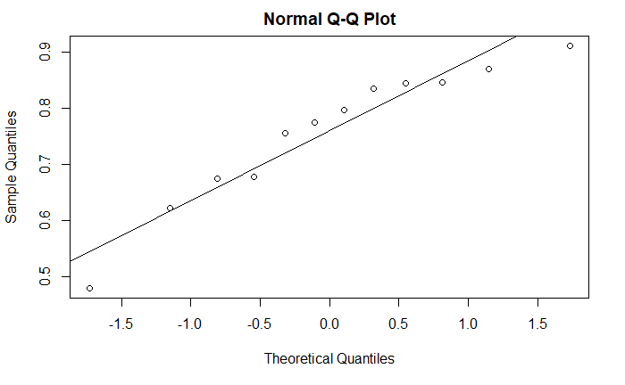

```
    Shapiro-Wilk normality test

data:  proportion.mammal.cameras$value
W = 0.91973, p-value = 0.2837
```

So…. sort of normal-ish? I’ll give it a shot. Is there is a significant difference between using counts or biomass?

```
    Welch Two Sample t-test

data:  proportion.mammal.cameras.wide$prop.mm.mass and proportion.mammal.cameras.wide$prop.mm.count
t = 2.3517, df = 6.6443, p-value = 0.05286
alternative hypothesis: true difference in means is not equal to 0
95 percent confidence interval:
 -0.002333406  0.285256720
sample estimates:
mean of x mean of y
0.8286182 0.6871566
```

So the two methods (biomass vs. counts) do give slightly different results. Which is interesting, because Lewis says they don’t. Generally, counts are more widely reported.

| nest | prop.av.mass | prop.av.count |
| --- | --- | --- |
| TCR2019 | 0.12368777 | 0.2150538 |
| MTF2019 | 0.13016915 | 0.1048951 |
| UTZ2019 | 0.08365151 | 0.1000000 |
| MTC2019 | 0.19990487 | 0.2641509 |
| TMC2019 | 0.20970130 | 0.4000000 |
| RLK2019 | 0.06217869 | 0.1081081 |

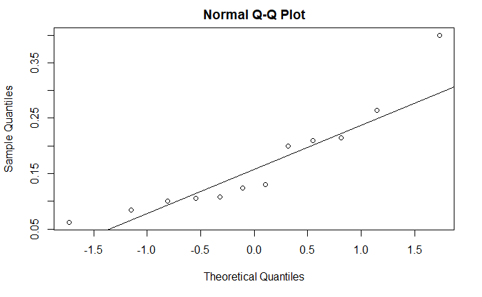

```
    Shapiro-Wilk normality test

data:  proportion.avian.cameras.long$value
W = 0.86707, p-value = 0.06


    Welch Two Sample t-test

data:  proportion.avian.cameras$prop.av.mass and proportion.avian.cameras$prop.av.count
t = -1.1671, df = 7.3447, p-value = 0.2797
alternative hypothesis: true difference in means is not equal to 0
95 percent confidence interval:
 -0.19190225  0.06426404
sample estimates:
mean of x mean of y
0.1348822 0.1987013
```

| nest | prop.sq.mass | prop.sq.count |
| --- | --- | --- |
| MTC2019 | 0.7172089 | 0.5660377 |
| MTF2019 | 0.7167476 | 0.6153846 |
| RLK2019 | 0.7755876 | 0.6486486 |
| TCR2019 | 0.8112324 | 0.6451613 |
| TMC2019 | 0.4872569 | 0.3200000 |
| UTZ2019 | 0.7271142 | 0.7600000 |

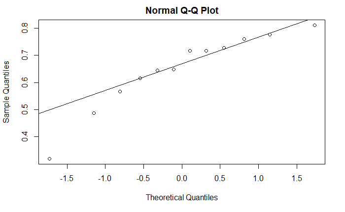

```
    Shapiro-Wilk normality test

data:  proportion.squirrel.cameras.long$value
W = 0.89802, p-value = 0.1496


    Welch Two Sample t-test

data:  proportion.squirrel.cameras$prop.sq.mass and proportion.squirrel.cameras$prop.sq.count
t = 1.4883, df = 9.3722, p-value = 0.1695
alternative hypothesis: true difference in means is not equal to 0
95 percent confidence interval:
 -0.05788184  0.28452027
sample estimates:
mean of x mean of y
0.7058579 0.5925387
```

The next thing to compare is cameras vs. remains. This cannot be grouped by site because the sample size for the remains + pellets data is too small.

| prop.sq.mass |
| --- |
| 0.139396 |

```
[1] 0.7058579
```

| prop.mm.mass |
| --- |
| 0.3747971 |

```
[1] 0.8286182
```

| prop.av.mass |
| --- |
| 0.6095253 |

```
[1] 0.1348822
```

I don’t even need to do any statistical tests to see these numbers are radically different. Like, horribly different. Like… I don’t even know what to do with these.

And on that depressing note, I think I’ll call it quits for the day.